# Simple Linear Regression - Categorical Predictor

Notes and in-class exercises

You can download the .qmd file for this activity here and open in R-studio. The rendered version is posted in the [course website](https://mutasim221b.github.io/Mac-STAT-155-Sp-26/) (Activities tab). I often experiment with the class activities (and see it in live!) and make updates, but I always post the final version before class starts. To be sure you have the most up-to-date copy, please download it once you’ve settled in before class begins.

# Notes

## Learning goals

By the end of this lesson, you should be able to:

- Write a **model formula** for a simple linear regression model with a categorical predictor using **indicator variables**
- Interpret the coefficients in a simple linear regression model with a categorical predictor

## Readings and videos

Complete *both* the reading and the videos to go through **before** class.

- Reading: Section 3.9 in the [STAT 155 Notes](https://mac-stat.github.io/Stat155Notes/) only up through section 3.9.1 Indicator Variables
- Videos:
  - [Simple linear regression: categorical predictor](https://youtu.be/QPpp6Kpk2To) ([slides](https://drive.google.com/file/d/1fbSJW4DhVWxR8rykowPUoAZ6WfzuZ857/view?usp=sharing))
  - [R Code for Categorical Predictors](https://voicethread.com/share/14980390/)

**File organization:** Save this file in the “Activities” subfolder of your “STAT155” folder.

# Exercises

**Context:** Today we’ll explore data on thousands of diamonds to understand how physical characteristics relate to price. Read in the data below.

```r
# Load packages and import data
library(tidyverse)
data(diamonds)

# A little bit of data wrangling code - let's not focus on this for now
diamonds <- diamonds %>%
    mutate(
        cut = factor(cut, ordered = FALSE),
        color = factor(color, ordered = FALSE),
        clarity = factor(clarity, ordered = FALSE)
    )
```

For the first several exercises, our focus will be on the relationship between diamond price and cut.

## Exercise 1: Get to know the data

Write R code to answer the following:

- 1. How many cases and variables do we have? What does a case represent?
- 2. What do the first few rows of the data look like?
- 3. Construct and interpret two different visualizations of the `price` variable.
- 4. Construct and interpret a visualization of the `cut` variable.

```r
dim(diamonds)
## [1] 53940    10

head(diamonds)
## # A tibble: 6 × 10
##   carat cut       color clarity depth table price     x     y     z
##   <dbl> <fct>     <fct> <fct>   <dbl> <dbl> <int> <dbl> <dbl> <dbl>
## 1  0.23 Ideal     E     SI2      61.5    55   326  3.95  3.98  2.43
## 2  0.21 Premium   E     SI1      59.8    61   326  3.89  3.84  2.31
## 3  0.23 Good      E     VS1      56.9    65   327  4.05  4.07  2.31
## 4  0.29 Premium   I     VS2      62.4    58   334  4.2   4.23  2.63
## 5  0.31 Good      J     SI2      63.3    58   335  4.34  4.35  2.75
## 6  0.24 Very Good J     VVS2     62.8    57   336  3.94  3.96  2.48

# Visualize price (outcome variable)
ggplot(diamonds, aes(x = price)) +
    geom_histogram()
```

[output not shown]

```r
ggplot(diamonds, aes(y = price)) +
    geom_boxplot()
```

[output not shown]

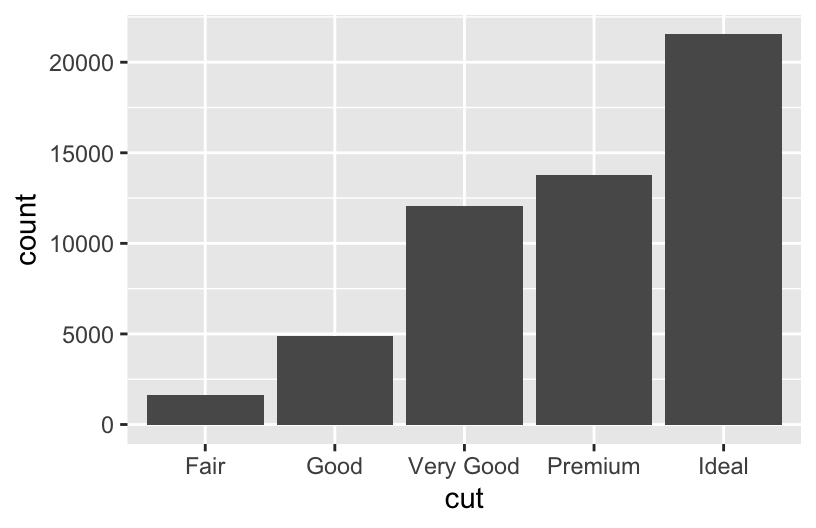

```r
diamonds %>%
    summarize(mean(price), median(price), sd(price))
## # A tibble: 1 × 3
##   `mean(price)` `median(price)` `sd(price)`
##           <dbl>           <dbl>       <dbl>
## 1         3933.            2401       3989.

# Visualize cut (predictor variable)
ggplot(diamonds, aes(x = cut)) +
    geom_bar()
```

```r
diamonds %>%
    count(cut)
## # A tibble: 5 × 2
##   cut           n
##   <fct>     <int>
## 1 Fair       1610
## 2 Good       4906
## 3 Very Good 12082
## 4 Premium   13791
## 5 Ideal     21551
```

## Exercise 2: Visualizations

Start by visualizing this relationship of interest, that between `price` and `cut`.

1. The appropriate plot depends upon the type of variables we’re plotting. When exploring the relationship between a quantitative response and a quantitative predictor, a scatterplot was an effective choice. After running the code below, explain why a scatterplot is not effective for exploring the relationship between the outcome price and *categorical* `cut` predictor.

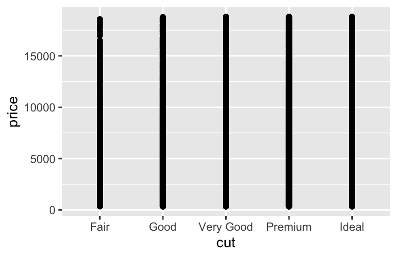

```r
# Try a scatterplot
ggplot(diamonds, aes(y = price, x = cut)) +
    geom_point()
```

> **Response:** Put your response here.
2. Separately run each chunk below, with two plots. Comment (`#`) on what changes in the code / output.

b.1.

```r
# Univariate boxplot
ggplot(diamonds, aes(y = price)) +
    geom_boxplot()
```

[output not shown]

> **Response:** Put your response here.

b.2.

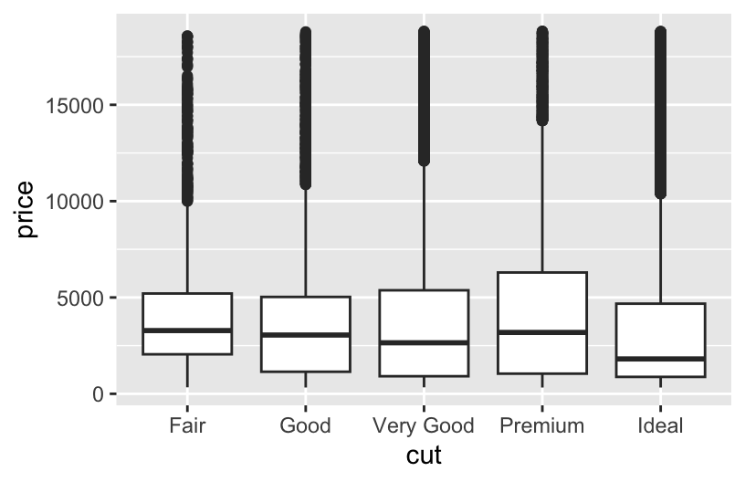

```r
# ???
ggplot(diamonds, aes(y = price, x = cut)) +
    geom_boxplot()
```

> **Response:** Put your response here.

b.3.

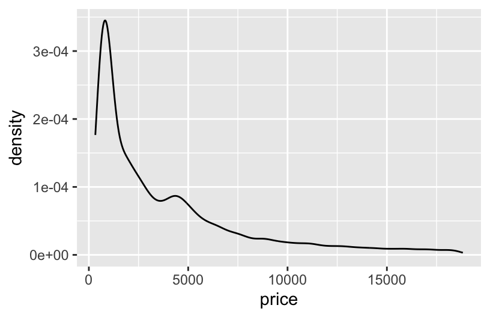

```r
# Univariate density plot
ggplot(diamonds, aes(x = price)) +
    geom_density()
```

> **Response:** Put your response here.

b.4.

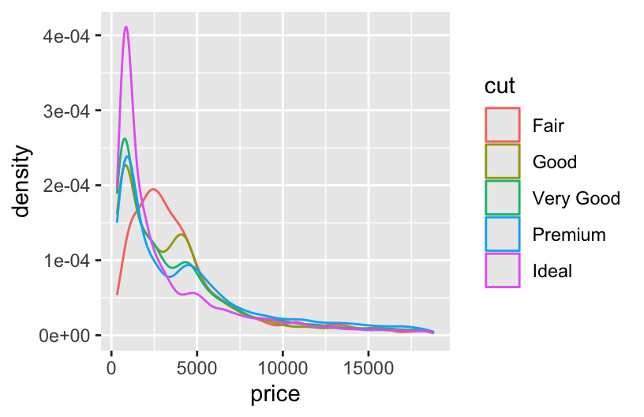

```r
# Comparisons in density plot
ggplot(diamonds, aes(x = price, color = cut)) +
    geom_density()
```

> **Response:** Put your response here.

b.5.

```r
# Univariate histogram
ggplot(diamonds, aes(x = price)) +
    geom_histogram()
```

[output not shown]

> **Response:** Put your response here.

b.6. What’s the difference between this and b4 density plot comparison? Can we now interpret the relationship between price and cut as we could in density plot? Why not?

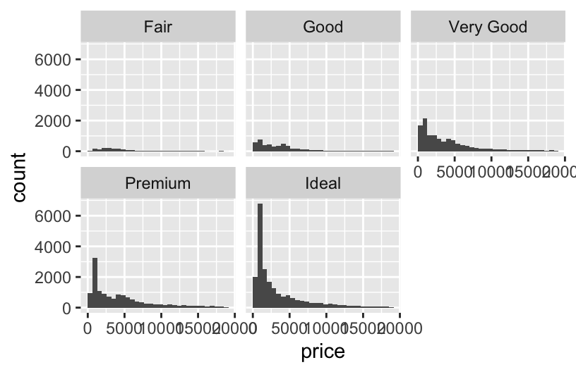

```r
# ???
ggplot(diamonds, aes(x = price)) +
    geom_histogram() +
    facet_wrap(~ cut)
```

> **Response:** Put your response here.
3. Do you notice anything interesting about the relationship between price and cut? What do you think might be happening here?

> **Response:** Put your response here.

## Exercise 3: Numerical summaries

Let’s follow up our plots with some numerical summaries.

1. To warm up, first calculate the mean `price` across all diamonds.

```r
diamonds %>%
     summarize(mean(price))
## # A tibble: 1 × 1
##   `mean(price)`
##           <dbl>
## 1         3933.
```

2. To summarize the trends we observed in the grouped plots above, we can calculate the mean `price` for each type of `cut`. This requires the inclusion of the `group_by()` function:

```r
# Calculate mean price by cut
diamonds %>%
    group_by(cut) %>%
    summarize(mean(price))
## # A tibble: 5 × 2
##   cut       `mean(price)`
##   <fct>             <dbl>
## 1 Fair              4359.
## 2 Good              3929.
## 3 Very Good         3982.
## 4 Premium           4584.
## 5 Ideal             3458.
```

The `ifelse` function allows to create a new variable from an existing one, based on whether or not the values in that variable meet a certain “condition” (remember, you can always look up function documentation in R by typing `?ifelse` in the Console, and hitting enter!).

Fill in the following code to create `cutFair`. The condition was given to you already. Try to use this to complete the code.

```r
# In the first blank, put what value cutFair should have if the condition is "met", or TRUE
# In the second blank, put what value cutFair should have if the condition is "not met", or FALSE
diamonds <- diamonds %>%
  mutate(cutFair=ifelse(cut == "Fair", 1, 0))
```

Variables like `cutFair` that are coded as 0/1 to numerically indicate if a categorical variable is at a particular state are known as an **indicator variable**. You will sometimes see these referred to as a “binary variable” or “dichotomous variable”; you may also encounter the term “dummy variable” in older statistical literature.

5. Now, let’s calculate the group means based on the new `cutFair` indicator variable:

```r
diamonds %>%
    group_by(cutFair) %>%
    summarize(mean(price))
## # A tibble: 2 × 2
##   cutFair `mean(price)`
##     <dbl>         <dbl>
## 1       0         3920.
## 2       1         4359.
```

## Exercise 4: Modeling trend using a categorical predictor with exactly 2 categories

Next, let’s *model* the trend in the relationship between the `cutFair` and `price` variables using a simple linear regression model:

```r
# Construct the model
diamond_mod0 <- lm(price ~ cutFair, data = diamonds)

# Summarize the model
summary(diamond_mod0)
##
## Call:
## lm(formula = price ~ cutFair, data = diamonds)
##
## Residuals:
##    Min     1Q Median     3Q    Max
##  -4022  -2977  -1529   1391  14903
##
## Coefficients:
##             Estimate Std. Error t value Pr(>|t|)
## (Intercept)  3919.69      17.44  224.80  < 2e-16 ***
## cutFair       439.06     100.93    4.35 1.36e-05 ***
## ---
## Signif. codes:  0 '***' 0.001 '**' 0.01 '*' 0.05 '.' 0.1 ' ' 1
##
## Residual standard error: 3989 on 53938 degrees of freedom
## Multiple R-squared:  0.0003507,  Adjusted R-squared:  0.0003322
## F-statistic: 18.93 on 1 and 53938 DF,  p-value: 1.362e-05
```

Compare these results to the output of exercise 3e. What do you notice? How do you interpret the intercept and `cutFair` coefficient terms from this model?

## Exercise 5: Modeling trend using a categorical predictor with >2 categories

Using a single binary predictor like the `cutFair` indicator variable is useful when there are two clearly delineated categories. However, the `cut` variable actually contains 5 categories! Because we’ve collapsed all non-Fair classifications into a single category (i.e. `cutFair = 0`), the model above can’t tell us anything about the difference in expected price between, say, *Premium* and *Ideal* cuts. The good news is that it is very straightforward to model categorical predictors with >2 categories. We can do this by using the `cut` variable as our predictor:

```r
# Construct the model
diamond_mod <- lm(price ~ cut, data = diamonds)

# Summarize the model
summary(diamond_mod)
##
## Call:
## lm(formula = price ~ cut, data = diamonds)
##
## Residuals:
##    Min     1Q Median     3Q    Max
##  -4258  -2741  -1494   1360  15348
##
## Coefficients:
##              Estimate Std. Error t value Pr(>|t|)
## (Intercept)   4358.76      98.79  44.122  < 2e-16 ***
## cutGood       -429.89     113.85  -3.776 0.000160 ***
## cutVery Good  -377.00     105.16  -3.585 0.000338 ***
## cutPremium     225.50     104.40   2.160 0.030772 *
## cutIdeal      -901.22     102.41  -8.800  < 2e-16 ***
## ---
## Signif. codes:  0 '***' 0.001 '**' 0.01 '*' 0.05 '.' 0.1 ' ' 1
##
## Residual standard error: 3964 on 53935 degrees of freedom
## Multiple R-squared:  0.01286,    Adjusted R-squared:  0.01279
## F-statistic: 175.7 on 4 and 53935 DF,  p-value: < 2.2e-16
```

1. Even though we specified a single predictor variable in the model, we are seeing 4 coefficient estimates–why do you think this is the case?

We are seeing 4 coefficient estimates because each category is being assigned to a separate indicator variable–`cutGood` = 1 when `cut == "Good"` and 0 otherwise, `cutVery Good` = 1 when `cut == “Very Good” and 0 otherwise, and so on.

NOTE: We see 4 indicator variables (for Good, Very Good, Premium, and Ideal), but we do not see `cutFair` in the model output. This is because `Fair` is the **reference level** of the `cut` variable (it’s first alphabetically).

2. After examining the summary table output from the code chunk above, complete the model formula:

E[price | cut] = 4358.7578 - 429.8933 cutGood - 376.9979 cutVery Good + 225.4999 cutPremium - 901.2158 cutIdeal

## Exercise 6: Making sense of the model

Recall our model: E[price | cut] = 4358.7578 - 429.8933 cutGood - 376.9979 cutVery Good + 225.4999 cutPremium - 901.2158 cutIdeal

1. Use the model formula to calculate the expected/typical price for diamonds of *Good* cut.
- Expected/typical price for diamonds of *Good* cut:

E[price | cut] = 4358.7578 - 429.8933 * 1 - 376.9979 * 0 + 225.4999 * 0 - 901.2158 * 0 = 4358.7578 - 429.8933 = $3928.865

```r
predict(diamond_mod, newdata = data.frame(cut = "Good"))
##        1
## 3928.864
```

2. Similarly, calculate the expected/typical price for diamonds of *Fair* cut.
- Expected/typical price for diamonds of *Fair* cut:

E[price | cut] = 4358.7578 - 429.8933 * 0 - 376.9979 * 0 + 225.4999 * 0 - 901.2158 * 0 = $4358.7578

```r
predict(diamond_mod, newdata = data.frame(cut = "Fair"))
##        1
## 4358.758
```

3. Re-examine these 2 calculations. Where have you seen these numbers before?!

These come from our group mean calculations in Exercise 3b! The predicted value for diamonds of *Fair* cut is also the same as what we obtained using the SLR model in exercise 4 with only a single `cutFair` indicator variable.

## Exercise 7: Interpreting coefficients

Recall that our model formula is *not a formula for a line*. Thus we can’t interpret the coefficients as “slopes” as we have before. Taking this into account and reflecting upon your calculations above…

1. Interpret the intercept coefficient (`4358.7578`) in terms of the data context. *Make sure to use non-causal language, include units, and talk about averages rather than individual cases.*

> The average price of a Fair cut diamonds is $4358.7578.
2. Interpret the `cutGood` and `cutVery Good` coefficients (`-429.8933` and `-376.9979`) in terms of the data context. Hint: where did you use these value in the prediction calculations above?
   - Interpretation of `cutGood` coefficient: On average, Good cut diamonds are worth $429.89 less than Fair cut diamonds.
   - Interpretation of `cutVery Good` coefficient: On average, Very Good cut diamonds are worth $377.00 less than Fair cut diamonds.

## Exercise 8: Modeling choices (CHALLENGE)

Why do we fit this model in this way (using 4 indicator variables `cutGood`, `cutVery Good`, `cutPremium`, `cutIdeal`)? Instead, suppose that we created a single variable `cutCat` that gave each category a numerical value: 0 for Fair, 1 for Good, 2 for Very Good, 3 for Premium, and 4 for Ideal.

How would this change things? What are the pros and cons of each approach?

## Render your work

- Click the “Render” button in the menu bar for this pane (blue arrow pointing right). This will create an HTML file containing all of the directions, code, and responses from this activity. A preview of the HTML will appear in the browser.
- Scroll through and inspect the document to check that your work translated to the HTML format correctly.
- Close the browser tab.
- Go to the “Background Jobs” pane in RStudio and click the Stop button to end the rendering process.
- Navigate to your “Activities” subfolder within your “STAT155” folder and locate the HTML file. You can open it again in your browser to double check.

# Additional Practice

## Exercise 9: The least squares criterion

The coefficient estimates `diamond_mod` were selected in the same way as when our predictor is quantitative: by minimizing the sum of the squared residuals. Use this model to calculate the residual for the first diamond in the dataset:

```r
# Observed data on the first diamond
diamonds %>%
  select(price, cut) %>%
  head(1)
## # A tibble: 1 × 2
##   price cut
##   <int> <fct>
## 1   326 Ideal
```

## Exercise 10: Diamond color

Consider modeling `price` by `color`.

- Before creating a visualization that shows the relationship between price and color, write down what you expect the plot to look like. Then construct and interpret an appropriate plot.
- Compute the average price for each color.
- Fit an appropriate linear model with `lm()` and display a short summary of the model.
- Write out the model formula from the above summary.
- Which color is the reference level? How can you tell from the model summary?
- Interpret the intercept and two other coefficients from the model in terms of the data context.

## Exercise 11: Diamond clarity

Repeat the steps from the previous exercise for the `clarity` variable.

## Exercise 12: Evaluating model strength

Let’s study some penguin data!

```r
data(penguins)
penguins <- penguins %>%
  filter(!is.na(sex), !is.na(species))
```

We’ll focus on 3 variables with the goal of predicting `flipper_len`:

- `flipper_len` = the length of the penguin’s flippers (arms) in mm
- `species` = Adelie, Chinstrap, or Gentoo
- `sex` = female, male

And build 2 models of `flipper_len`:

```r
# Model of flipper_len by sex
flipper_model_1 <- lm(flipper_len ~ sex, data = penguins)
flipper_model_2 <- lm(flipper_len ~ species, data = penguins)
```

Just as with models that use *quantitative* predictors, it’s important to *evaluate* our (eventual) models of `flipper_len` by `species` and `sex`: are they correct? strong? fair?

Let’s start with strength. How strong are these models? What’s the best predictor? Let’s explore.

1. Based on the boxplots below, what is the stronger predictor of `flipper_len`: `sex` or `species`?

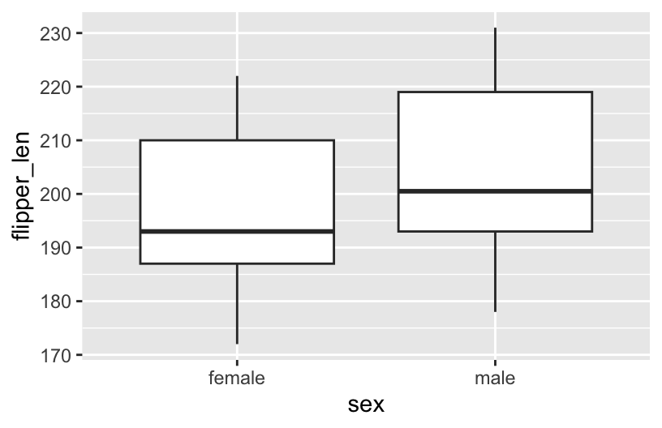

```r
penguins %>%
  ggplot(aes(y = flipper_len, x = sex)) +
  geom_boxplot()
```

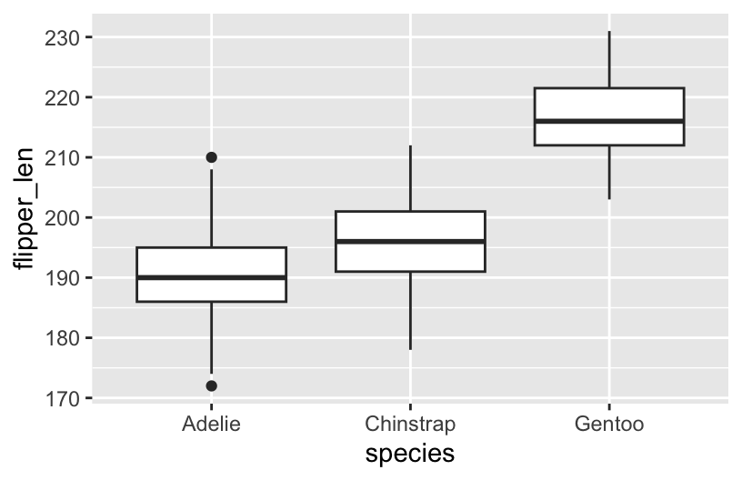

```r
penguins %>%
  ggplot(aes(y = flipper_len, x = species)) +
  geom_boxplot()
```

2. We used 2 approaches to measuring the strength of the simple linear regression models in previous activities: correlation and R-squared. Unfortunately, we get errors when we try to calculate the correlation between `flipper_len` and `sex`, and between `flipper_len` and `species`. Why?

```r
penguins %>%
  summarize(cor(sex, flipper_len))
## Error in `summarize()`:
## ℹ In argument: `cor(sex, flipper_len)`.
## Caused by error in `cor()`:
## ! 'x' must be numeric
penguins %>%
  summarize(cor(species, flipper_len))
## Error in `summarize()`:
## ℹ In argument: `cor(species, flipper_len)`.
## Caused by error in `cor()`:
## ! 'x' must be numeric
```

3. Luckily, R-squared works no matter whether a predictor is quantitative or categorical! Interpret and compare the R-squared values for our separate models of `flipper_len` by `sex` and `species`. Which is the stronger predictor? Does this match your answer in part a?

```r
# Model of flipper_len by sex
summary(flipper_model_1)
##
## Call:
## lm(formula = flipper_len ~ sex, data = penguins)
##
## Residuals:
##     Min      1Q  Median      3Q     Max
## -26.506 -10.364  -4.364  12.636  26.494
##
## Coefficients:
##             Estimate Std. Error t value Pr(>|t|)
## (Intercept)  197.364      1.057 186.792  < 2e-16 ***
## sexmale        7.142      1.488   4.801 2.39e-06 ***
## ---
## Signif. codes:  0 '***' 0.001 '**' 0.01 '*' 0.05 '.' 0.1 ' ' 1
##
## Residual standard error: 13.57 on 331 degrees of freedom
## Multiple R-squared:  0.06511,    Adjusted R-squared:  0.06229
## F-statistic: 23.05 on 1 and 331 DF,  p-value: 2.391e-06

# Model of flipper_len by species
summary(flipper_model_2)
##
## Call:
## lm(formula = flipper_len ~ species, data = penguins)
##
## Residuals:
##      Min       1Q   Median       3Q      Max
## -18.1027  -4.8235  -0.1027   4.7647  19.8973
##
## Coefficients:
##                  Estimate Std. Error t value Pr(>|t|)
## (Intercept)      190.1027     0.5522  344.25  < 2e-16 ***
## speciesChinstrap   5.7208     0.9796    5.84 1.25e-08 ***
## speciesGentoo     27.1326     0.8241   32.92  < 2e-16 ***
## ---
## Signif. codes:  0 '***' 0.001 '**' 0.01 '*' 0.05 '.' 0.1 ' ' 1
##
## Residual standard error: 6.673 on 330 degrees of freedom
## Multiple R-squared:  0.7747, Adjusted R-squared:  0.7734
## F-statistic: 567.4 on 2 and 330 DF,  p-value: < 2.2e-16
```

## Exercise 13: Evaluating model correctness

Let’s just focus on the stronger of our 2 models, that of `flipper_len` by `species` (`flipper_model_2`), and ask: is it correct (not wrong)? Recall that when our predictor was *quantitative*, residual plots provided some insight. Check out the residual plots below. They look a little goofy! Explain the goofiness (what’s happening here) and describe what you learn about the model’s “correctness”. Is the model “correct”?

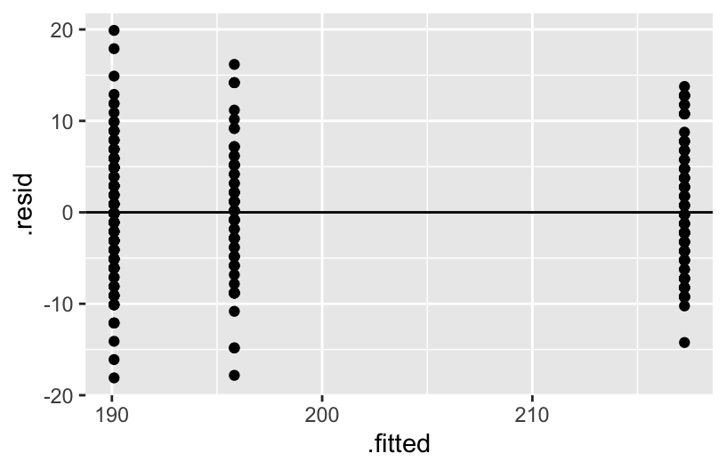

```r
# Residual plot
flipper_model_2 %>%
  ggplot(aes(x = .fitted, y = .resid)) +
  geom_point() +
  geom_hline(yintercept = 0)
```

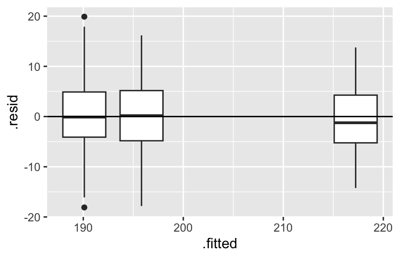

```r
# Residual plot using boxes!
flipper_model_2 %>%
  ggplot(aes(x = .fitted, y = .resid, group = .fitted)) +
  geom_boxplot() +
  geom_hline(yintercept = 0)
```

## Exercise 14: Really understand how the coefficients work

Next, consider the model of `flipper_len` by `island`. The average `flipper_len` of penguins on each `island` is calculated below:

```r
penguins %>%
  group_by(island) %>%
  summarize(mean(flipper_len))
## # A tibble: 3 × 2
##   island    `mean(flipper_len)`
##   <fct>                   <dbl>
## 1 Biscoe                   210.
## 2 Dream                    193.
## 3 Torgersen                192.
```

1. Using just the above averages and your understanding of categorical predictors, fill in the model coefficients and indicator variables below. Do NOT use `lm()` yet!!!

E[`flipper_len` | `island`] = ___ +/- ___ island??? +/- ___ island???

2. Check your work to Part a.

```r
flipper_model_3 <- lm(flipper_len ~ island, penguins)
summary(flipper_model_3)
##
## Call:
## lm(formula = flipper_len ~ island, data = penguins)
##
## Residuals:
##     Min      1Q  Median      3Q     Max
## -37.558  -5.532   1.468   7.442  21.442
##
## Coefficients:
##                 Estimate Std. Error t value Pr(>|t|)
## (Intercept)      209.558      0.879 238.410   <2e-16 ***
## islandDream      -16.371      1.340 -12.214   <2e-16 ***
## islandTorgersen  -18.026      1.858  -9.702   <2e-16 ***
## ---
## Signif. codes:  0 '***' 0.001 '**' 0.01 '*' 0.05 '.' 0.1 ' ' 1
##
## Residual standard error: 11.22 on 330 degrees of freedom
## Multiple R-squared:  0.3628, Adjusted R-squared:  0.3589
## F-statistic: 93.94 on 2 and 330 DF,  p-value: < 2.2e-16
```

# Solutions

## Exercise 1: Get to know the data

- A case represents a single diamond.
- The distribution of price is right skewed with considerable high outliers. The right skew is evidenced by the mean price ($3932) being much higher than the median price ($2401).
- Most diamonds in this data are of Good cut or better. Ideal cut diamonds are the most common with each succesive grade being the next most common.

```r
dim(diamonds)
## [1] 53940    11

head(diamonds)
## # A tibble: 6 × 11
##   carat cut       color clarity depth table price     x     y     z cutFair
##   <dbl> <fct>     <fct> <fct>   <dbl> <dbl> <int> <dbl> <dbl> <dbl>   <dbl>
## 1  0.23 Ideal     E     SI2      61.5    55   326  3.95  3.98  2.43       0
## 2  0.21 Premium   E     SI1      59.8    61   326  3.89  3.84  2.31       0
## 3  0.23 Good      E     VS1      56.9    65   327  4.05  4.07  2.31       0
## 4  0.29 Premium   I     VS2      62.4    58   334  4.2   4.23  2.63       0
## 5  0.31 Good      J     SI2      63.3    58   335  4.34  4.35  2.75       0
## 6  0.24 Very Good J     VVS2     62.8    57   336  3.94  3.96  2.48       0

# Visualize price (outcome variable)
ggplot(diamonds, aes(x = price)) +
    geom_histogram()
```

[output not shown]

```r
ggplot(diamonds, aes(y = price)) +
    geom_boxplot()
```

[output not shown]

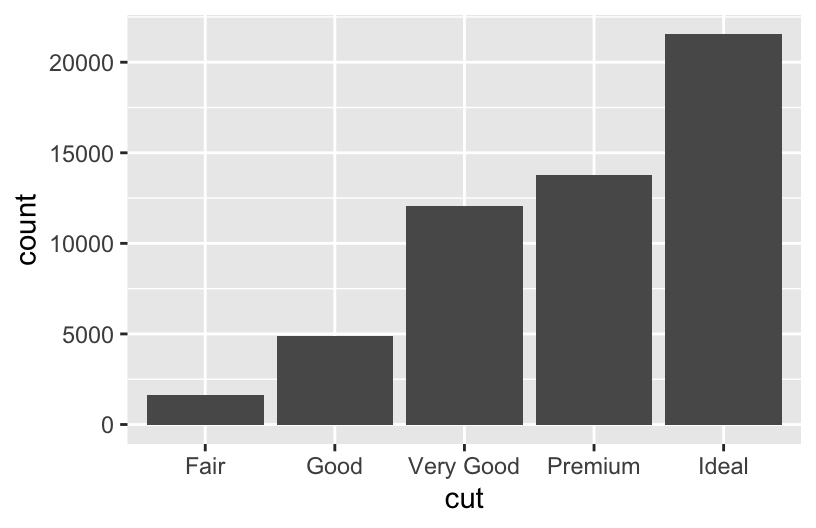

```r
diamonds %>%
    summarize(mean(price), median(price), sd(price))
## # A tibble: 1 × 3
##   `mean(price)` `median(price)` `sd(price)`
##           <dbl>           <dbl>       <dbl>
## 1         3933.            2401       3989.

# Visualize cut (predictor variable)
ggplot(diamonds, aes(x = cut)) +
    geom_bar()
```

```r
diamonds %>%
    count(cut)
## # A tibble: 5 × 2
##   cut           n
##   <fct>     <int>
## 1 Fair       1610
## 2 Good       4906
## 3 Very Good 12082
## 4 Premium   13791
## 5 Ideal     21551
```

## Exercise 2: Visualizations

Start by visualizing this relationship of interest, that between `price` and `cut`.

1. We just don’t see anything clearly on a scatterplot. With the small number of unique values of the predictor variable, all of the points are bunched up on each other.

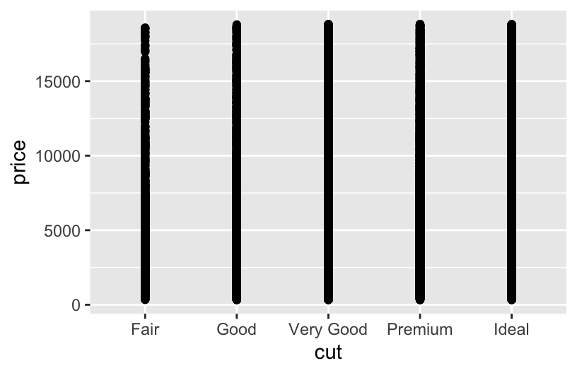

```r
# Try a scatterplot
ggplot(diamonds, aes(y = price, x = cut)) +
    geom_point()
```

2. Separately run each chunk below, with two plots. Comment (`#`) on what changes in the code / output.

```r
# Univariate boxplot
ggplot(diamonds, aes(y = price)) +
    geom_boxplot()
```

[output not shown]

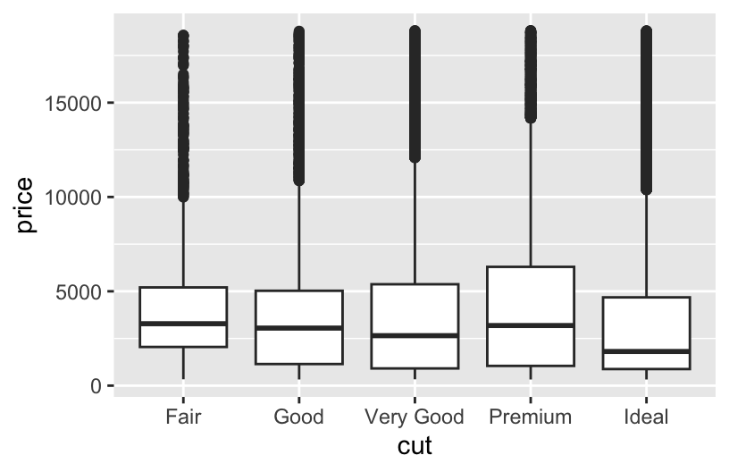

```r
# Separate boxes by category
ggplot(diamonds, aes(y = price, x = cut)) +
    geom_boxplot()
```

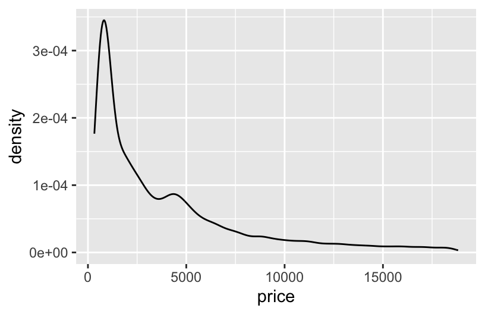

```r
# Univariate density plot
ggplot(diamonds, aes(x = price)) +
    geom_density()
```

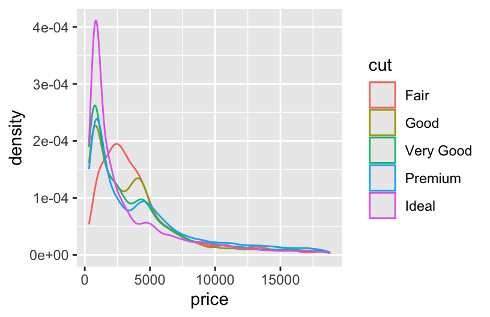

```r
# Separate density plots by category
ggplot(diamonds, aes(x = price, color = cut)) +
    geom_density()
```

```r
# Univariate histogram
ggplot(diamonds, aes(x = price)) +
    geom_histogram()
```

[output not shown]

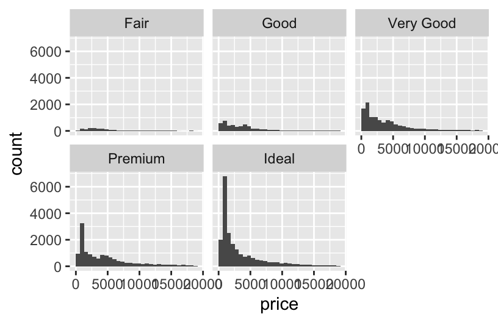

```r
# Separate histograms by category
ggplot(diamonds, aes(x = price)) +
    geom_histogram() +
    facet_wrap(~ cut)
```

## Exercise 3: Numerical summaries

Let’s follow up our plots with some numerical summaries.

1. Mean `price` across all diamonds:

```r
diamonds %>%
    summarize(mean(price))
## # A tibble: 1 × 1
##   `mean(price)`
##           <dbl>
## 1         3933.
```

2. Mean `price` for each type of `cut`:

```r
diamonds %>%
    group_by(cut) %>%
    summarize(mean(price))
## # A tibble: 5 × 2
##   cut       `mean(price)`
##   <fct>             <dbl>
## 1 Fair              4359.
## 2 Good              3929.
## 3 Very Good         3982.
## 4 Premium           4584.
## 5 Ideal             3458.
```

3. Group means should reflect what you see in the plots (easiest to see in the boxplots)
4. Create our new `cutFair` variable:

```r
diamonds <- diamonds %>%
  mutate(cutFair=ifelse(cut == "Fair", 1, 0))
```

5. Calculate the group means based on this new variable

```r
diamonds %>%
    group_by(cutFair) %>%
    summarize(mean(price))
## # A tibble: 2 × 2
##   cutFair `mean(price)`
##     <dbl>         <dbl>
## 1       0         3920.
## 2       1         4359.
```

## Exercise 4: Modeling trend using a categorical predictor with exactly 2 categories

```r
# Construct the model
diamond_mod0 <- lm(price ~ cutFair, data = diamonds)

# Summarize the model
coef(summary(diamond_mod0))
##              Estimate Std. Error    t value     Pr(>|t|)
## (Intercept) 3919.6946    17.4367 224.795616 0.000000e+00
## cutFair      439.0632   100.9269   4.350309 1.361951e-05
```

The intercept is the expected value (mean) of the price for all diamonds with a cut quality that isn’t Fair (Good, Very Good, Premium, or Ideal, i.e. when `cutFair` = 0)–the same as we saw in exercise 3e.

3. When we add the intercept and coefficient for `cutFair`, we get `3919.69 + 439.06 = 4358.75`–this is the mean price for all diamonds with a Fair cut quality that we saw in exercise 3e! Therefore, the coefficient of `cutFair` (439.06) is interpreted as the difference between the mean value of diamonds with a Fair cut quality and the mean value of diamonds with a higher cut quality.

## Exercise 5: Modeling trend using a categorical predictor with >2 categories

```r
# Construct the model
diamond_mod <- lm(price ~ cut, data = diamonds)

# Summarize the model
coef(summary(diamond_mod))
##               Estimate Std. Error   t value     Pr(>|t|)
## (Intercept)  4358.7578   98.78795 44.122361 0.000000e+00
## cutGood      -429.8933  113.84940 -3.775982 1.595493e-04
## cutVery Good -376.9979  105.16422 -3.584849 3.375707e-04
## cutPremium    225.4999  104.39521  2.160060 3.077240e-02
## cutIdeal     -901.2158  102.41155 -8.799943 1.408406e-18
```

1. We are seeing 4 coefficient estimates because each category is being assigned to a separate indicator variable–`cutGood` = 1 when `cut == "Good"` and 0 otherwise, `cutVery Good` = 1 when `cut == “Very Good” and 0 otherwise, and so on.
2. E[price | cut] = 4358.7578 - 429.8933 cutGood - 376.9979 cutVery Good + 225.4999 cutPremium - 901.2158 cutIdeal

## Exercise 6: Making sense of the model

1. Expected/typical price for diamonds of *Good* cut:

E[price | cut] = 4358.7578 - 429.8933 * 1 - 376.9979 * 0 + 225.4999 * 0 - 901.2158 * 0 = 4358.7578 - 429.8933 = $3928.865

```r
predict(diamond_mod, newdata = data.frame(cut = "Good"))
##        1
## 3928.864
```

2. Expected/typical price for diamonds of *Fair* cut:

E[price | cut] = 4358.7578 - 429.8933 * 0 - 376.9979 * 0 + 225.4999 * 0 - 901.2158 * 0 = $4358.7578

```r
predict(diamond_mod, newdata = data.frame(cut = "Fair"))
##        1
## 4358.758
```

3. These come from our group mean calculations in Exercise 3b! The predicted value for diamonds of *Fair* cut is also the same as what we obtained using the SLR model in exercise 4 with only a single `cutFair` indicator variable.

## Exercise 7: Interpreting coefficients

Recall that our model formula is *not a formula for a line*. Thus we can’t interpret the coefficients as “slopes” as we have before. Taking this into account and reflecting upon your calculations above…

1. The average price of a Fair cut diamonds is $4358.7578.
2. - Interpretation of `cutGood` coefficient: On average, Good cut diamonds are worth $429.89 less than Fair cut diamonds.
   - Interpretation of `cutVery Good` coefficient: On average, Very Good cut diamonds are worth $377.00 less than Fair cut diamonds.

## Exercise 8: Modeling choices (CHALLENGE)

Why do we fit this model in this way (using 4 indicator variables `cutGood`, `cutVery Good`, `cutPremium`, `cutIdeal`)? Instead, suppose that we created a single variable `cutCat` that gave each category a numerical value: 0 for Fair, 1 for Good, 2 for Very Good, 3 for Premium, and 4 for Ideal.

- If we used 0-4 instead of creating indicator variables, we would be constraining the change from 0 to 1, from 1 to 2, etc. to always be of the same magnitude. That is, a 1 unit change in the cut variable would always have the same change in price in our model.
- Using separate indicator variables allows the difference between subsequent categories to be different, which allows our model to be a bit more nuanced. It is possible to take nuance too far though. For example, in our previous investigations of bikeshare data, we modeled ridership versus temperature. We treated temperature as a quantitative predictor. Imagine if we had created an indicator variable for each unique temperature in the data—that would be so many variables! Having so many variables creates a very complex model which can be hard to make sense of. (These ideas are addressed further in STAT 253: Statistical Machine Learning!)

## Exercise 9: The least squares criterion

```r
# Observed price = 326
diamonds %>%
  select(price, cut) %>%
  head(1)
## # A tibble: 1 × 2
##   price cut
##   <int> <fct>
## 1   326 Ideal

# Predicted price = 3457.542
predict(diamond_mod, newdata = data.frame(cut = "Ideal"))
##        1
## 3457.542

# Residual
326 - 3457.542
## [1] -3131.542
```

## Exercise 10: Diamond color

Consider modeling `price` by `color`.

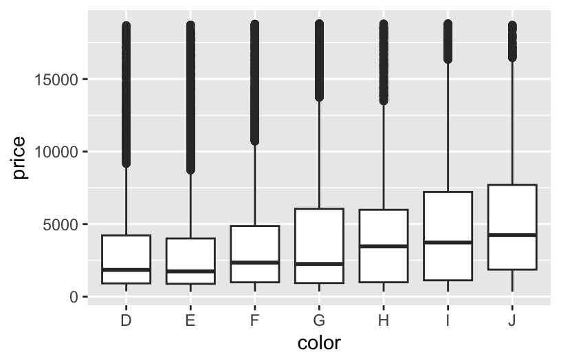

```r
ggplot(diamonds, aes(x = color, y = price)) +
    geom_boxplot()
```

```r
diamonds %>%
    group_by(color) %>%
    summarize(mean(price))
## # A tibble: 7 × 2
##   color `mean(price)`
##   <fct>         <dbl>
## 1 D             3170.
## 2 E             3077.
## 3 F             3725.
## 4 G             3999.
## 5 H             4487.
## 6 I             5092.
## 7 J             5324.
```

- We fit a linear model and obtain the model formula: E[price | color] = 3169.95 - 93.20 colorE + 554.93 colorF + 829.18 colorG + 1316.72 colorH + 1921.92 colorI + 2153.86 colorJ

```r
diamond_mod2 <- lm(price ~ color, data = diamonds)

coef(summary(diamond_mod2))
##               Estimate Std. Error   t value      Pr(>|t|)
## (Intercept) 3169.95410   47.70694 66.446391  0.000000e+00
## colorE       -93.20162   62.04724 -1.502107  1.330752e-01
## colorF       554.93230   62.38527  8.895246  6.004834e-19
## colorG       829.18158   60.34470 13.740751  6.836340e-43
## colorH      1316.71510   64.28715 20.481777  7.074714e-93
## colorI      1921.92086   71.55308 26.860072 7.078041e-158
## colorJ      2153.86392   88.13203 24.439060 3.414906e-131
```

- Color D is the reference level because we don’t see its indicator variable in the model output.
- Interpretation of the intercept: Diamonds with D color cost $3169.95 on average.
- Interpretation of the `colorE` coefficient: Diamonds with E color cost $93.20 **less** than D color diamonds on average.
- Interpretation of the `colorF` coefficient: Diamonds with F color cost $554.93 **more** than D color diamonds on average.

## Exercise 11: Diamond clarity

We see the unexpected result that diamonds of better clarity (VS1 and higher) have lower average prices. In fact the best clarity diamonds (VVS1 and IF) have the *lowest* average prices. What might be going on? What if the most clear diamonds were also quite small…

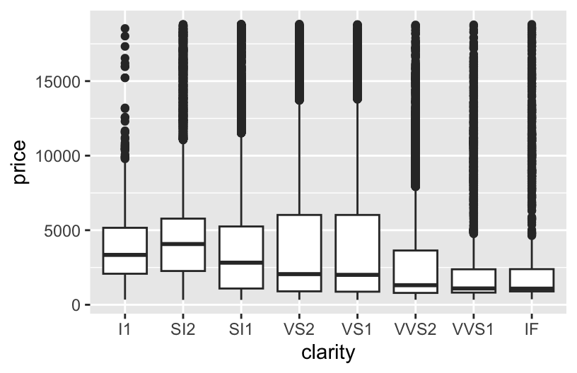

```r
ggplot(diamonds, aes(x = clarity, y = price)) +
    geom_boxplot()
```

```r
diamonds %>%
    group_by(clarity) %>%
    summarize(mean(price))
## # A tibble: 8 × 2
##   clarity `mean(price)`
##   <fct>           <dbl>
## 1 I1              3924.
## 2 SI2             5063.
## 3 SI1             3996.
## 4 VS2             3925.
## 5 VS1             3839.
## 6 VVS2            3284.
## 7 VVS1            2523.
## 8 IF              2865.

diamond_mod3 <- lm(price ~ clarity, data = diamonds)

coef(summary(diamond_mod3))
##                  Estimate Std. Error      t value      Pr(>|t|)
## (Intercept)  3924.1686910   144.5619 27.145247517 3.513547e-161
## claritySI2   1138.8599147   150.2746  7.578526239  3.550711e-14
## claritySI1     71.8324571   148.6049  0.483378837  6.288287e-01
## clarityVS2      0.8207037   148.8672  0.005512992  9.956013e-01
## clarityVS1    -84.7132999   150.9746 -0.561109670  5.747251e-01
## clarityVVS2  -640.4316203   154.7737 -4.137858008  3.510944e-05
## clarityVVS1 -1401.0540535   158.5401 -8.837224284  1.010097e-18
## clarityIF   -1059.3295848   171.8990 -6.162510636  7.210567e-10
```

## Exercise 12: Evaluating model strength

```r
flipper_model_1 <- lm(flipper_len ~ sex, data = penguins)
flipper_model_2 <- lm(flipper_len ~ species, data = penguins)
```

### Part a

`species` appears to be the stronger predictor - the `flipper_len` values are more distinct between species (there’s less overlap in the boxes)

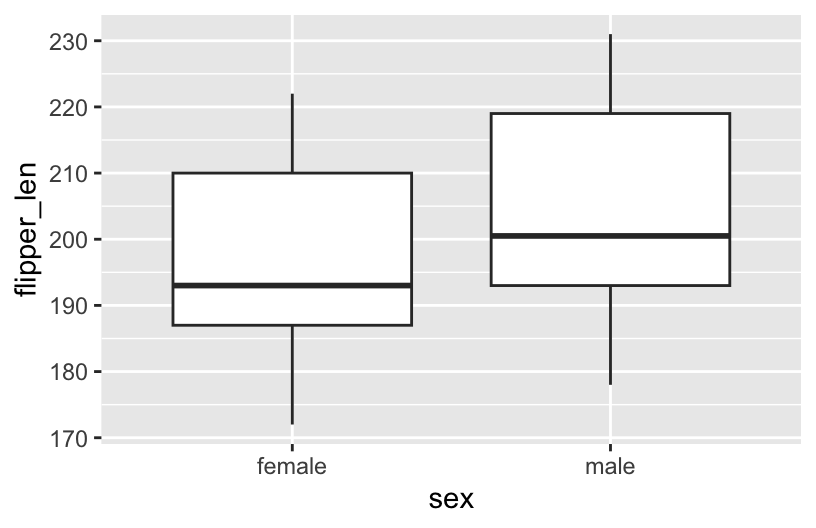

```r
data(penguins)
penguins <- penguins %>%
  filter(!is.na(sex), !is.na(species))

penguins %>%
  ggplot(aes(y = flipper_len, x = sex)) +
  geom_boxplot()
```

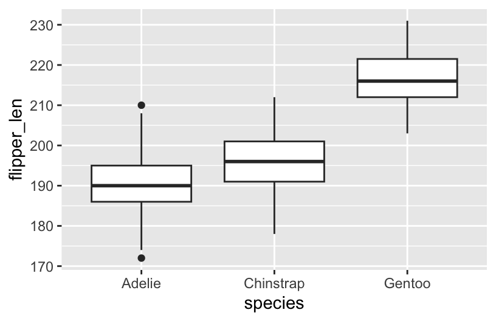

```r
penguins %>%
  ggplot(aes(y = flipper_len, x = species)) +
  geom_boxplot()
```

### Part b

Correlation only works when both variables in the pair are *quantitative*, but `sex` and `species` are *categorical*.

### Part c

Using `sex`: R-squared = 0.06511

```r
summary(flipper_model_1)
##
## Call:
## lm(formula = flipper_len ~ sex, data = penguins)
##
## Residuals:
##     Min      1Q  Median      3Q     Max
## -26.506 -10.364  -4.364  12.636  26.494
##
## Coefficients:
##             Estimate Std. Error t value Pr(>|t|)
## (Intercept)  197.364      1.057 186.792  < 2e-16 ***
## sexmale        7.142      1.488   4.801 2.39e-06 ***
## ---
## Signif. codes:  0 '***' 0.001 '**' 0.01 '*' 0.05 '.' 0.1 ' ' 1
##
## Residual standard error: 13.57 on 331 degrees of freedom
## Multiple R-squared:  0.06511,    Adjusted R-squared:  0.06229
## F-statistic: 23.05 on 1 and 331 DF,  p-value: 2.391e-06
summary(flipper_model_2)
##
## Call:
## lm(formula = flipper_len ~ species, data = penguins)
##
## Residuals:
##      Min       1Q   Median       3Q      Max
## -18.1027  -4.8235  -0.1027   4.7647  19.8973
##
## Coefficients:
##                  Estimate Std. Error t value Pr(>|t|)
## (Intercept)      190.1027     0.5522  344.25  < 2e-16 ***
## speciesChinstrap   5.7208     0.9796    5.84 1.25e-08 ***
## speciesGentoo     27.1326     0.8241   32.92  < 2e-16 ***
## ---
## Signif. codes:  0 '***' 0.001 '**' 0.01 '*' 0.05 '.' 0.1 ' ' 1
##
## Residual standard error: 6.673 on 330 degrees of freedom
## Multiple R-squared:  0.7747, Adjusted R-squared:  0.7734
## F-statistic: 567.4 on 2 and 330 DF,  p-value: < 2.2e-16
```

## Exercise 13: Evaluating model correctness

Since there are only 3 different `species`, there are only 3 possible predictions of `flipper_len` in this model (one per species). Thus each of the 3 groups on the x-axis corresponds to a species. Within each species, the observed `flipper_len` deviates from the species-based prediction, thus so too do the residuals. That’s why the points in each group have different y coordinates.

Overall, our model doesn’t seem too wrong! No matter the x value (species!), the residuals are normally balanced above and below 0 with roughly equal variance in each species.

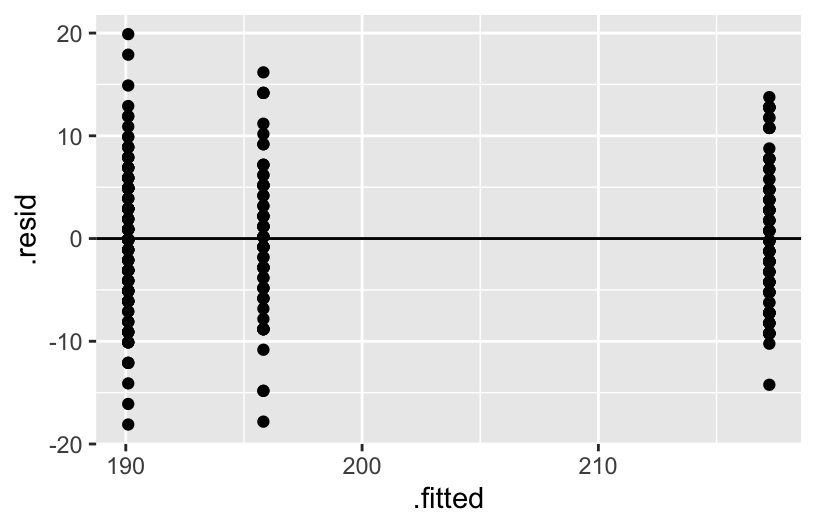

```r
# Residual plot
flipper_model_2 %>%
  ggplot(aes(x = .fitted, y = .resid)) +
  geom_point() +
  geom_hline(yintercept = 0)
```

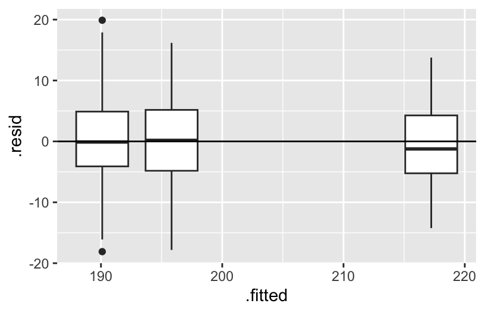

```r
# Residual plot using boxes!
flipper_model_2 %>%
  ggplot(aes(x = .fitted, y = .resid, group = .fitted)) +
  geom_boxplot() +
  geom_hline(yintercept = 0)
```

## Exercise 14: Really understand how the coefficients work

```r
penguins %>%
  group_by(island) %>%
  summarize(mean(flipper_len))
## # A tibble: 3 × 2
##   island    `mean(flipper_len)`
##   <fct>                   <dbl>
## 1 Biscoe                   210.
## 2 Dream                    193.
## 3 Torgersen                192.
```

1. E[`flipper_len` | `island`] = 209.56 - 16.37 islandDream - 18.03 islandTorgersen

Why?

- The island terms are `islandDream` and `islandTorgersen` since Biscoe is the reference.
- The intercept is the average flipper length for the reference, Biscoe.
- The `islandDream` coefficient reflects the fact that the average flipper length on Dream is 16.37mm *lower* than that on Biscoe (193.1870 - 209.5583)
- The `islandTorgersen` coefficient reflects the fact that the average flipper length on Dream is 18.03mm *lower* than that on Biscoe (191.5319 - 209.5583)

```r
flipper_model_3 <- lm(flipper_len ~ island, penguins)
summary(flipper_model_3)
##
## Call:
## lm(formula = flipper_len ~ island, data = penguins)
##
## Residuals:
##     Min      1Q  Median      3Q     Max
## -37.558  -5.532   1.468   7.442  21.442
##
## Coefficients:
##                 Estimate Std. Error t value Pr(>|t|)
## (Intercept)      209.558      0.879 238.410   <2e-16 ***
## islandDream      -16.371      1.340 -12.214   <2e-16 ***
## islandTorgersen  -18.026      1.858  -9.702   <2e-16 ***
## ---
## Signif. codes:  0 '***' 0.001 '**' 0.01 '*' 0.05 '.' 0.1 ' ' 1
##
## Residual standard error: 11.22 on 330 degrees of freedom
## Multiple R-squared:  0.3628, Adjusted R-squared:  0.3589
## F-statistic: 93.94 on 2 and 330 DF,  p-value: < 2.2e-16
```